# RegressionModels

# Multivariate Examples & Tricks

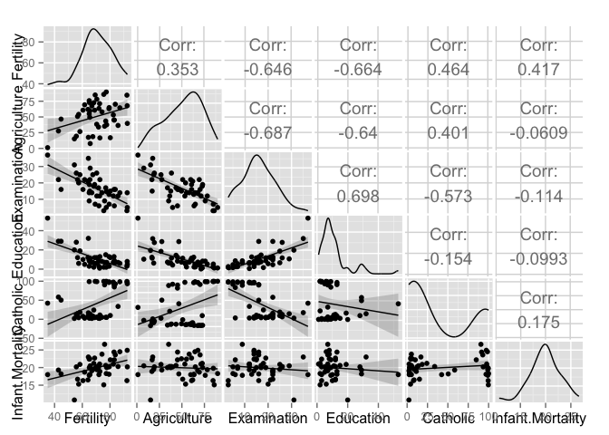

```r
require(datasets)
require(GGally)
## Loading required package: GGally
##
## Attaching package: 'GGally'
##
## The following object is masked from 'package:dplyr':
##
##     nasa
require(ggplot2)

data("swiss")
#?swiss
g <- ggpairs(swiss, lower = list(continuous = "smooth"), params = c(method = "loess"))
g
```

```r
#lets see the result of calling lm on this datase
summary(lm(Fertility ~ ., data = swiss))
##
## Call:
## lm(formula = Fertility ~ ., data = swiss)
##
## Residuals:
##      Min       1Q   Median       3Q      Max
## -15.2743  -5.2617   0.5032   4.1198  15.3213
##
## Coefficients:
##                  Estimate Std. Error t value Pr(>|t|)
## (Intercept)      66.91518   10.70604   6.250 1.91e-07 ***
## Agriculture      -0.17211    0.07030  -2.448  0.01873 *
## Examination      -0.25801    0.25388  -1.016  0.31546
## Education        -0.87094    0.18303  -4.758 2.43e-05 ***
## Catholic          0.10412    0.03526   2.953  0.00519 **
## Infant.Mortality  1.07705    0.38172   2.822  0.00734 **
## ---
## Signif. codes:  0 '***' 0.001 '**' 0.01 '*' 0.05 '.' 0.1 ' ' 1
##
## Residual standard error: 7.165 on 41 degrees of freedom
## Multiple R-squared:  0.7067, Adjusted R-squared:  0.671
## F-statistic: 19.76 on 5 and 41 DF,  p-value: 5.594e-10
summary(lm(Fertility ~ ., data = swiss))$coef
##                    Estimate  Std. Error   t value     Pr(>|t|)
## (Intercept)      66.9151817 10.70603759  6.250229 1.906051e-07
## Agriculture      -0.1721140  0.07030392 -2.448142 1.872715e-02
## Examination      -0.2580082  0.25387820 -1.016268 3.154617e-01
## Education        -0.8709401  0.18302860 -4.758492 2.430605e-05
## Catholic          0.1041153  0.03525785  2.952969 5.190079e-03
## Infant.Mortality  1.0770481  0.38171965  2.821568 7.335715e-03

#Unudjusted estimates
summary(lm(Fertility ~ Agriculture, data = swiss))
##
## Call:
## lm(formula = Fertility ~ Agriculture, data = swiss)
##
## Residuals:
##      Min       1Q   Median       3Q      Max
## -25.5374  -7.8685  -0.6362   9.0464  24.4858
##
## Coefficients:
##             Estimate Std. Error t value Pr(>|t|)
## (Intercept) 60.30438    4.25126  14.185   <2e-16 ***
## Agriculture  0.19420    0.07671   2.532   0.0149 *
## ---
## Signif. codes:  0 '***' 0.001 '**' 0.01 '*' 0.05 '.' 0.1 ' ' 1
##
## Residual standard error: 11.82 on 45 degrees of freedom
## Multiple R-squared:  0.1247, Adjusted R-squared:  0.1052
## F-statistic: 6.409 on 1 and 45 DF,  p-value: 0.01492

summary(lm(Fertility ~ Agriculture + Education + Examination, data = swiss))
##
## Call:
## lm(formula = Fertility ~ Agriculture + Education + Examination,
##     data = swiss)
##
## Residuals:
##     Min      1Q  Median      3Q     Max
## -14.967  -4.978  -1.045   4.906  21.358
##
## Coefficients:
##             Estimate Std. Error t value Pr(>|t|)
## (Intercept) 99.80162    7.15523  13.948  < 2e-16 ***
## Agriculture -0.18017    0.08071  -2.232  0.03084 *
## Education   -0.67242    0.19366  -3.472  0.00119 **
## Examination -0.79744    0.24679  -3.231  0.00237 **
## ---
## Signif. codes:  0 '***' 0.001 '**' 0.01 '*' 0.05 '.' 0.1 ' ' 1
##
## Residual standard error: 8.601 on 43 degrees of freedom
## Multiple R-squared:  0.5568, Adjusted R-squared:  0.5259
## F-statistic: 18.01 on 3 and 43 DF,  p-value: 1.017e-07
```

**Homework 1**  
1. Load datase Seatbelts and fit a linear mode of driver deaths (response) with kms and petrol as predictors.

2. Repeat question 1 for the outcome being the log of the count of driver deaths. Interpret your coefficients.
3. Add the dummy variable law and interpret the results. Repeat this question with a factor variable that you create called lawFactor that takes the levels No and Yes. Change the reference level from No to Yes.
4. Discretize the PetrolPrice variable into four factor levels. Fit the linear model with this factor to see how R treats multiple level factor variables

```r
library(datasets)
data("Seatbelts")

#Setabealts is a time series object so we need to transform into a dataframe
seatbelts <- as.data.frame(Seatbelts)
head(seatbelts)
##   DriversKilled drivers front rear   kms PetrolPrice VanKilled law
## 1           107    1687   867  269  9059   0.1029718        12   0
## 2            97    1508   825  265  7685   0.1023630         6   0
## 3           102    1507   806  319  9963   0.1020625        12   0
## 4            87    1385   814  407 10955   0.1008733         8   0
## 5           119    1632   991  454 11823   0.1010197        10   0
## 6           106    1511   945  427 12391   0.1005812        13   0

fit <- lm(DriversKilled ~ kms + PetrolPrice, data = seatbelts)
summary(fit)$coefficients
##                  Estimate   Std. Error   t value     Pr(>|t|)
## (Intercept)  2.157461e+02 1.466559e+01 14.711047 3.772201e-33
## kms         -1.749546e-03 6.145401e-04 -2.846919 4.902428e-03
## PetrolPrice -6.437895e+02 1.482896e+02 -4.341435 2.304713e-05
round(summary(fit)$coef,4)
##              Estimate Std. Error t value Pr(>|t|)
## (Intercept)  215.7461    14.6656 14.7110   0.0000
## kms           -0.0017     0.0006 -2.8469   0.0049
## PetrolPrice -643.7895   148.2896 -4.3414   0.0000
```

```r
library(datasets)
data("Seatbelts")
seatbelts <- as.data.frame(Seatbelts)
#2.
#logging of the outcome
library(dplyr)
#normalized in order to have a better scale
seatbelts <- mutate(seatbelts,
                   pp = (PetrolPrice - mean(PetrolPrice)) / sd(PetrolPrice),
                   mm = kms / 1000,
                   mmc = mm - mean(mm))
head(seatbelts)
##   DriversKilled drivers front rear   kms PetrolPrice VanKilled law
## 1           107    1687   867  269  9059   0.1029718        12   0
## 2            97    1508   825  265  7685   0.1023630         6   0
## 3           102    1507   806  319  9963   0.1020625        12   0
## 4            87    1385   814  407 10955   0.1008733         8   0
## 5           119    1632   991  454 11823   0.1010197        10   0
## 6           106    1511   945  427 12391   0.1005812        13   0
##            pp     mm       mmc
## 1 -0.05356454  9.059 -5.934604
## 2 -0.10356653  7.685 -7.308604
## 3 -0.12824699  9.963 -5.030604
## 4 -0.22591505 10.955 -4.038604
## 5 -0.21389350 11.823 -3.170604
## 6 -0.24990592 12.391 -2.602604

fit <- lm(I(log(DriversKilled)) ~ mmc + pp, data = seatbelts)
summary(fit)$coefficients
##                Estimate  Std. Error    t value      Pr(>|t|)
## (Intercept)  4.78966306 0.013426810 356.723817 2.737888e-269
## mmc         -0.01400794 0.004962149  -2.822959  5.267843e-03
## pp          -0.06412578 0.014579039  -4.398492  1.818005e-05

#All of the estimates are now interpreted in the log scale. We can then
exp( -0.06412578)
## [1] 0.937887
1 - exp( -0.06412578)
## [1] 0.06211298
#circa 6% decrease in geometric mean death for a 1 sd increase in pp holding mmc constant.
#3.
fit <- lm(DriversKilled ~ mmc + pp + law, data = seatbelts)
summary(fit)
##
## Call:
## lm(formula = DriversKilled ~ mmc + pp + law, data = seatbelts)
##
## Residuals:
##    Min     1Q Median     3Q    Max
## -50.69 -17.29  -4.05  14.33  60.71
##
## Coefficients:
##             Estimate Std. Error t value Pr(>|t|)
## (Intercept) 124.2263     1.8012  68.967  < 2e-16 ***
## mmc          -1.2233     0.6657  -1.838 0.067676 .
## pp           -6.9199     1.8514  -3.738 0.000246 ***
## law         -11.8892     6.0258  -1.973 0.049955 *
## ---
## Signif. codes:  0 '***' 0.001 '**' 0.01 '*' 0.05 '.' 0.1 ' ' 1
##
## Residual standard error: 22.87 on 188 degrees of freedom
## Multiple R-squared:  0.201,  Adjusted R-squared:  0.1882
## F-statistic: 15.76 on 3 and 188 DF,  p-value: 3.478e-09
#The law variable is an factor variable and this doesc change our intercept.
#124 (intercept) is the expected number of death for the average ppn, the average km and before the law was in effect (law zero).
#If we want to know the intercept when the law was in effect we need to add -11.889 to the previous value. 11.889 fewer death were because of the law being in effect.
#Other variable are interpreted as before (with law variable constant (zero or one)
```

```r
#4.
library(datasets)
data("Seatbelts")
seatbelts <- as.data.frame(Seatbelts)
seatbelts <- mutate(seatbelts,
                   pp = (PetrolPrice - mean(PetrolPrice)) / sd(PetrolPrice),
                   ppf = as.factor((pp <=-1.5)+(pp<=0)+(pp<=1.5)+(pp<Inf)),
                   mm = kms / 1000,
                   mmc = mm - mean(mm))
head(seatbelts)
##   DriversKilled drivers front rear   kms PetrolPrice VanKilled law
## 1           107    1687   867  269  9059   0.1029718        12   0
## 2            97    1508   825  265  7685   0.1023630         6   0
## 3           102    1507   806  319  9963   0.1020625        12   0
## 4            87    1385   814  407 10955   0.1008733         8   0
## 5           119    1632   991  454 11823   0.1010197        10   0
## 6           106    1511   945  427 12391   0.1005812        13   0
##            pp ppf     mm       mmc
## 1 -0.05356454   3  9.059 -5.934604
## 2 -0.10356653   3  7.685 -7.308604
## 3 -0.12824699   3  9.963 -5.030604
## 4 -0.22591505   3 10.955 -4.038604
## 5 -0.21389350   3 11.823 -3.170604
## 6 -0.24990592   3 12.391 -2.602604
table(seatbelts$ppf)
##
##  1  2  3  4
##  6 96 71 19

fit <- lm(DriversKilled ~ mmc + ppf + law, data = seatbelts)
summary(fit)
##
## Call:
## lm(formula = DriversKilled ~ mmc + ppf + law, data = seatbelts)
##
## Residuals:
##     Min      1Q  Median      3Q     Max
## -53.384 -17.211  -3.421  14.849  65.613
##
## Coefficients:
##             Estimate Std. Error t value Pr(>|t|)
## (Intercept) 109.8405     9.5066  11.554   <2e-16 ***
## mmc          -1.2991     0.7668  -1.694   0.0919 .
## ppf2         10.8271     9.9462   1.089   0.2778
## ppf3         18.6904     9.9374   1.881   0.0616 .
## ppf4         25.0074    10.9163   2.291   0.0231 *
## law         -15.3445     6.0345  -2.543   0.0118 *
## ---
## Signif. codes:  0 '***' 0.001 '**' 0.01 '*' 0.05 '.' 0.1 ' ' 1
##
## Residual standard error: 23.24 on 186 degrees of freedom
## Multiple R-squared:  0.1833, Adjusted R-squared:  0.1614
## F-statistic:  8.35 on 5 and 186 DF,  p-value: 3.835e-07

#ppf1 is used (choosen) as a reference value - while the other are used explicitly in the model. Each coefficient estimate (ppf2, ppf3, ppf4) is interpreted as a comparison to the reference level.
```